# Patrones Puntuales

#### 2.0.4.2 2. Estimación de la intensidad

Se considero una estimación no paramétrica de la intensidad ($\lambda(s)$) mediante un **kernel Gaussiano bivariado**, asumiendo isotropía.

$$\hat{\lambda}(u) = \sum_{i=1}^n \frac{1}{2\pi\sigma^2} \exp\left(-\frac{d(u, x_i)^2}{2\sigma^2}\right)$$

donde:

- $u$: cualquier lugar de Colombia.
- $x_i$: cada sismo observado.
- $d(u, x_i)$: distancia desde el lugar al sismo.
- $\sigma$: controla qué tan lejos influye cada sismo.

Para fines descriptivos se decidió utilizar un ancho de banda donde se optimizara el error de predicción, el algoritmo consiste en que por cada valor de ancho de banda:

1. Eliminar un sismo.
2. Estimar la intensidad.
3. Evaluar en el sismo retirado.
4. Calcular criterio de calidad.

El ancho de banda que minimizo mejor el error de predicción fue de aproximadamente $18.75$ km.

```r
# 2. Cálculo de la Densidad Kernel Continua en spatstat
# El objeto sismos_ppp ya está escalado a kilómetros automáticamente
sigma <- bw.diggle(sismos_ppp)
mapa_densidad_sp <- density(unmark(sismos_ppp),sigma = sigma)

# 3. TRUCO GEOMÉTRICO: Conversión de formato .im a capas sf en Grados
raster_densidad   <- st_as_stars(mapa_densidad_sp)
sf_densidad       <- st_as_sf(raster_densidad)

# Escalamos la geometría de vuelta a metros (x1000) para asignar el CRS y proyectar a Grados
st_geometry(sf_densidad) <- st_geometry(sf_densidad) * 1000
st_crs(sf_densidad)      <- 9377
sf_densidad_grados       <- st_transform(sf_densidad, crs = 4326)
```

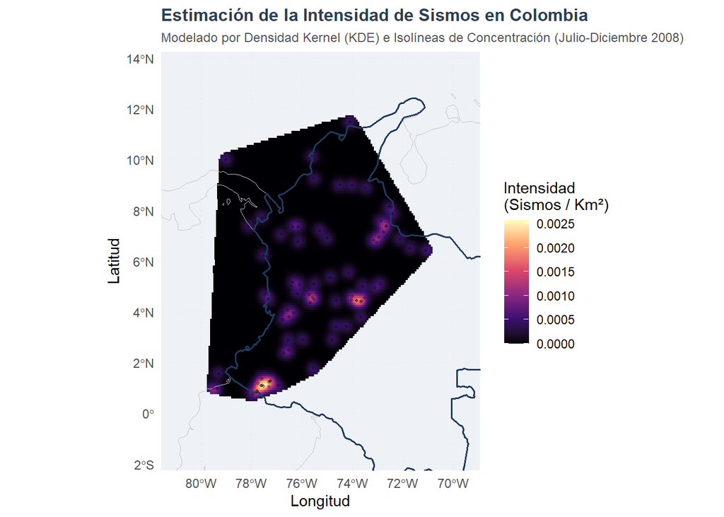

Figure 2.6: Estimación de la intensidad de sismos en Colombia

```r
# 4. Generación del gráfico de alta calidad cartográfica con ggplot2
ggplot() +
  # Capa 1: El mapa de calor continuo (Densidad Kernel)
  geom_sf(data = sf_densidad_grados, aes(fill = v), color = NA) +

  # Escala de colores Magma (Amarillo = Alta concentración / Peligro)
  scale_fill_viridis_c(option = "magma",
                        name = "Intensidad\n(Sismos / Km²)",
                        na.value = "transparent") +

  # Capa 2: Contorno de países colindantes (Fondo transparente)
  geom_sf(data = paises_vecinos, fill = NA, color = "#bdc3c7", linewidth = 0.3) +

  # Capa 3: Resaltar la frontera de Colombia
  geom_sf(data = colombia_map, fill = NA, color = "#1f3a60", linewidth = 0.7) +

  # Capa 4: Los sismos reales superpuestos como puntos guía negros y translúcidos
  geom_sf(data = sismos_sf, color = "#000000", size = 0.8, alpha = 0.3) +

  # Ajuste de encuadre oficial del SGC
  coord_sf(crs = st_crs(4326),
           xlim = c(-81, -69.5),
           ylim = c(-1.5, 13.5)) +

  # Títulos y etiquetas solicitadas (Actualizado el período a tu caso)
  labs(title = "Estimación de la Intensidad de Sismos en Colombia",
       subtitle = "Modelado por Densidad Kernel (KDE) e Isolíneas de Concentración (Julio-Diciembre 2008)",
       x = "Longitud", y = "Latitud") +

  theme_minimal() +
  theme(
    panel.grid.major = element_line(color = "gray93", linetype = "dotted"),
    plot.title = element_text(face = "bold", size = 12, color = "#2c3e50"),
    plot.subtitle = element_text(size = 9, italic = TRUE, color = "#555555"),
    panel.background = element_rect(fill = "#eef2f7", color = NA) # Océano azul claro
  )
```

Observando el gráfico 2.6 se concluye que la actividad sísmica se concentra en regiones asociadas a la cordillera de los Andes:

1. **Suroccidente:** En **Nariño** y **el Cauca**, esto geologicamente tiene sentido debido a la interacción entre las **placas Naza y Sudamericana.**
2. **Centro-sur andino:** Aproximadamente entre **Huila, Tolima, Meta** y **Cundinamarca**
3. **Eje Cafetero:** Se identifica un foco secundario entre **Quindío**, **Risaralda**, **norte del Valle del Cauca** y **Tolima**, región caracterizada por una elevada actividad sísmica asociada a sistemas de fallas andinas.

## 2.1 4. Análisis de segundo orden

### 2.1.1 Función k de Ripley

Sabemos que hay zonas con mayor intensidad, pero habrá zonas cuyos sismos dependan de otros, es decir, ¿el que ocurra un segundo sismo depende del primero?.

En un patrón no homogéneo, la relación entre la intensidad de segundo orden ($\lambda_2$) y las intensidades individuales ($\lambda(s)$) se describe mediante la función de intensidad $\rho(h)$, definida como:

$$\rho(h) = \frac{\lambda_2(s_i, s_j)}{\lambda(s_i)\lambda(s_j)}$$

A partir de esta relación, la función K para el caso inhomogéneo se define teóricamente como la integral de esta correlación:

$$K_{inhom}(r) = 2\pi \int_0^r \rho(u)u \, du$$
#### Formulación de Hipótesis Estadísticas

- Hipótesis Nula ($H_0$): Los eventos son independientes, por lo tanto $\lambda_2(s_i, s_j)=\lambda(s_i)\lambda(s_j) \rightarrow \rho(h) = 1$. En consecuencia, el patrón se comporta como un proceso de Poisson no homogéneo (CSR inhomogénea).
- Hipótesis Alternativa ($H_1$):Aun después de considerar la intensidad espacial $\lambda(s)$, los eventos no son independientes, es decir,
  $$\lambda_2(s_i, s_j)\neq\lambda(s_i)\lambda(s_j) \rightarrow \rho(h) \neq 1$$
  Esto indica la existencia de interacción espacial de segundo orden, manifestada como agregación ($\rho(h) > 1$) o inhibición ($\rho(h) < 1$) entre los eventos.

Aunque se calculó la función K con corrección isotrópica y de borde, para futuros análisis se reportarán principalmente los resultados obtenidos mediante la corrección de traslación. Además de esto, para el análisis de segundo orden se utilizó un ancho de banda en la estimación de la intensidad menos estricto, siendo aproximadamente 7 veces más grande que en la parte descriptiva ($\sigma \approx 124.45$), esto, con el fin de poder tener una intensidad más suavizada y manejable computacionalmente.

A continuación se emplea la función *K inhomogénea* (**Kinhom**), la cual incorpora una estimación de la intensidad local y permite evaluar la estructura espacial de segundo orden una vez controlada la heterogeneidad de primer orden.

La formula que lleva a cabo la función es:

$$\hat{K}_{inhom}(r) = \sum_{i \neq j} \frac{1(d_{ij} \leq r)}{\lambda(x_i) \lambda(x_j)e_{ij}}$$
donde:

- $d_{ij}:$ distancia euclidiana entre los sismos $i$ y $j$.
- $1(d_{ij}\leq r):$: función indicadora que toma el valor 1 si la distancia entre los sismos $i$ y $j$ es menor o igual que $r$, y 0 en caso contrario.
- $\hat{\lambda}(x_i)$: intensidad estimada mediante Kernel Density Estimation (KDE) en la ubicación del sismo $i$.
- $\hat{\lambda}(x_i)$: intensidad estimada mediante KDE en la ubicación del sismo $j$.
- $e_{ij}$: factor de corrección por efecto de borde. En este trabajo se empleó la corrección translate, la cual ajusta la contribución de los pares de puntos cuya vecindad se encuentra parcialmente fuera de la ventana de observación.
- $r$: distancia máxima considerada para contabilizar los pares de sismos.

```r
lambda_s <- density(unmark(sismos_ppp))
attributes(lambda_s)$sigma
```

```
## [1] 124.4499
```

```r
K_sismos_NH <- Kinhom(
  unmark(sismos_ppp),
  lambda_s,
  correction = "translate"
)
# 1. Calcular las bandas de confianza usando Kinhom
# Pasamos lambda_s y los argumentos adicionales usando funargs
env_kinhom <- envelope(
  unmark(sismos_ppp),
  fun = Kinhom,
  nsim = 499,
  simulate = expression(rpoispp(lambda_s)), # Simula bajo el proceso inhomogéneo
  funargs = list(lambda = lambda_s, correction = "translate")
)
```

```
## Generating 499 simulations by evaluating expression  ...
## 1, 2, 3, .5....10....15....20....25....30....35....40....45....50..
## ..55....60....65....70....75....80....85....90....95....100....105....110
## ....115....120....125....130....135....140....145....150....155....160....165...
## .170....175....180....185....190....195....200....205....210....215....220....225.
## ...230....235....240....245....250....255....260....265....270....275....280....
## 285....290....295....300....305....310....315....320....325....330....335....340..
## ..345....350....355....360....365....370....375....380....385....390....395....400
## ....405....410....415....420....425....430....435....440....445....450....455...
## .460....465....470....475....480....485....490....495...
## 499.
##
## Done.
```

```r
# 2. Convertir los resultados de spatstat a Data Frames
df_Kinhom <- as.data.frame(K_sismos_NH) # Usa el objeto K_sismos_NH que ya calculaste
df_env    <- as.data.frame(env_kinhom)

# 3. Construir el primer gráfico (Kinhom con diferentes correcciones si deseas,
# o graficar la que calculaste con "translate")
g1 <- ggplot(df_Kinhom, aes(x = r)) +
  geom_line(aes(y = trans, color = "Translate")) +
  geom_line(aes(y = theo, color = "Teórica"), linetype = "dashed") +
  labs(
    title = "Función K Inhomogénea\ncon corrección de borde",
    x = "Distancia (r)",
    y = "K_inhom(r)",
    color = "Corrección"
  ) +
  theme_minimal() +
  theme(plot.title = element_text(size = 10, face = "bold", hjust = 0.5))

# 4. Construir el segundo gráfico (Envelope de la función K inhomogénea)
g2 <- ggplot(df_env, aes(x = r)) +
  # Sombra gris para las bandas de confianza (mínimo y máximo simulado)
  geom_ribbon(aes(ymin = lo, ymax = hi), fill = "grey80", alpha = 0.5) +
  # Línea teórica esperada (proceso de Poisson homogéneo/inhomogéneo de referencia)
  geom_line(aes(y = mmean), color = "red", linetype = "dashed") +
  # Línea observada en tus datos reales
  geom_line(aes(y = obs), color = "black", linewidth = 0.8) +
  labs(
    title = "Bandas de confianza para\nla función K Inhomogénea",
    x = "Distancia (r)",
    y = "K_inhom(r)"
  ) +
  theme_minimal() +
  theme(plot.title = element_text(size = 10, face = "bold", hjust = 0.5))

# 5. Combinar ambos gráficos
mosaico4 <- g1 + g2
```

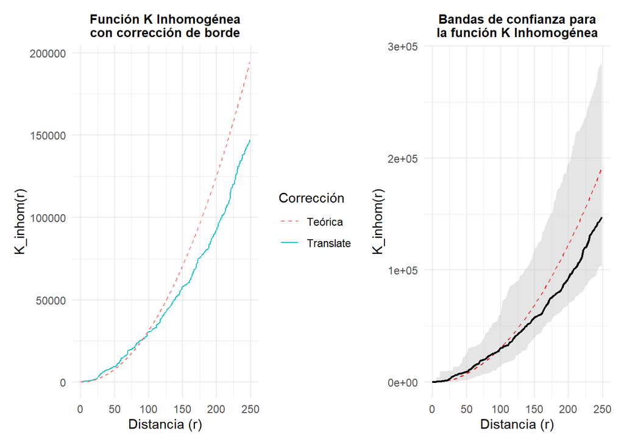

Figure 2.7: Función K de ripley eliminando la heterogeneidad

```r
plot(mosaico4)
```

El gráfico 2.7 muestra que una vez controlada la heterogeneidad mediante la función K inhomogénea, no existe evidencia de agregación, es decir los eventos son independientes.

### 2.1.2 Función L de Besag

Su relación con función **K de Ripley** es:

$$L_{inhom}=\sqrt{\frac{K_{inhom}}{\pi}}$$

Es utilizada debido a su fácil interpretación.

#### 2.1.2.1 Formulación de Hipótesis Estadísticas

- Hipótesis Nula ($H_0$): Los eventos son independientes, por lo tanto $\lambda_2(s_i, s_j)=\lambda(s_i)\lambda(s_j) \rightarrow \rho(h) = 1$, y por ende se comporta como aleatoriedad espacial completa (CSR, por sus siglas en inglés).
- Hipótesis Alternativa ($H_1$): El patrón sísmico presenta heterogeneidad espacial o interacciones de segundo orden (agregación o inhibición). La intensidad ($\lambda$) varía significativamente en el espacio.

Para tener una comparativa con la función **K de Ripley** se decidió reportar solamente la correción por **Traslación**.

A continuación se emplea la función *L inhomogénea* (**Linhom**), la cual incorpora una estimación de la intensidad local y permite evaluar la estructura espacial de segundo orden una vez controlada la heterogeneidad de primer orden.

```r
set.seed(1030)
# 1. Calcular las bandas de confianza usando Jest
Lenvel <- envelope(unmark(sismos_ppp),
  fun = Linhom,
  nsim = 499,
  simulate = expression(rpoispp(lambda_s)),
  funargs = list(
    lambda = lambda_s,
    correction = "translate"))
```

```
## Generating 499 simulations by evaluating expression  ...
## 1, 2, 3, .5....10....15....20....25....30....35....40....45....50..
## ..55....60....65....70....75....80....85....90....95....100....105....110
## ....115....120....125....130....135....140....145....150....155....160....165...
## .170....175....180....185....190....195....200....205....210....215....220....225.
## ...230....235....240....245....250....255....260....265....270....275....280....
## 285....290....295....300....305....310....315....320....325....330....335....340..
## ..345....350....355....360....365....370....375....380....385....390....395....400
## ....405....410....415....420....425....430....435....440....445....450....455...
## .460....465....470....475....480....485....490....495...
## 499.
##
## Done.
```

```r
# 2. Convertir los resultados de spatstat a Data Frames
df_Lest <- as.data.frame(Linhom(unmark(sismos_ppp),
                                lambda = lambda_s,
                                correction = "translate"))
df_env  <- as.data.frame(Lenvel)

# 3. Construir el primer gráfico (Jest con las correcciones reales de la Función J)
# 3. Construir el primer gráfico (Alineado con tus columnas reales de df_Jest)
g1 <- ggplot(df_Lest, aes(x = r)) +
  geom_line(aes(y = trans, color = "Translación")) +
  geom_line(aes(y = theo, color = "Teórica"), linetype = "dashed") +
  labs(
    title = "Función L de Besag con diferentes\ncorrecciones de borde",
    x = "Distancia (r)",
    y = "L(r)",
    color = "Corrección"
  ) +
  theme_minimal() +
  theme(plot.title = element_text(size = 10, face = "bold", hjust = 0.5))

# 4. Construir el segundo gráfico (Envelope de la función J)
g2 <- ggplot(df_env, aes(x = r)) +
  # Sombra gris para las bandas de confianza
  geom_ribbon(aes(ymin = lo, ymax = hi), fill = "grey80", alpha = 0.5) +
  # Línea teórica esperada (Confirmado: en tu objeto sí se llama 'theo')
  geom_line(aes(y = mmean), color = "red", linetype = "dashed") +
  # Línea observada en tus datos reales
  geom_line(aes(y = obs), color = "black", linewidth = 0.8) +
  labs(
    title = "Bandas de confianza para\nla función L de Besag",
    x = "Distancia (r)",
    y = "L(r)"
  ) +
  theme_minimal() +
  theme(plot.title = element_text(size = 10, face = "bold", hjust = 0.5))

# 5. Combinar ambos gráficos sin errores
mosaico6 <- g1 + g2
```

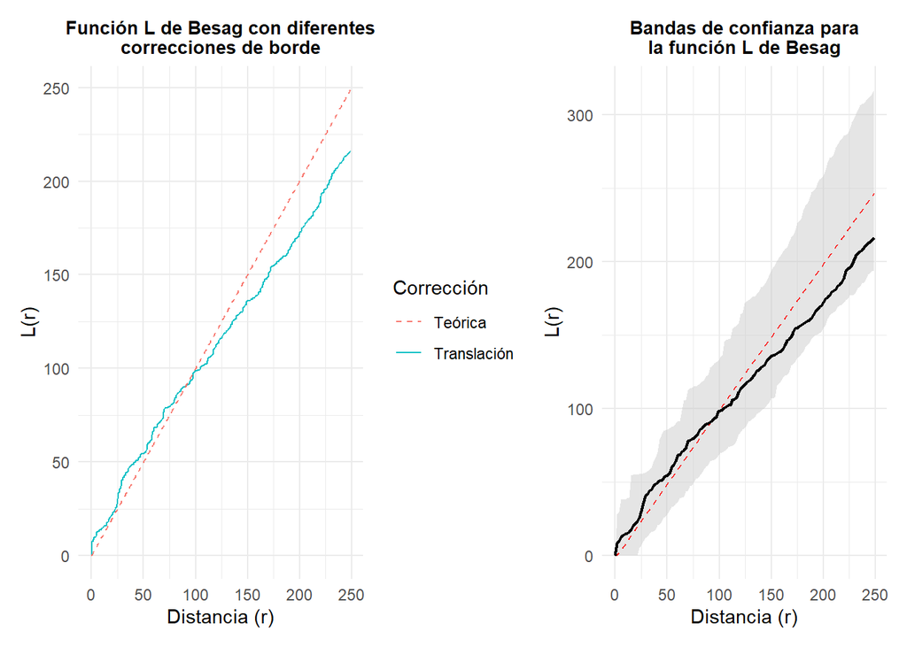

Figure 2.8: Función L de Besag eliminando la heterogeneidad

```r
plot(mosaico6)
```

Al incorporar una intensidad espacial variable estimada mediante KDE y evaluar la función L inhomogénea (Figura 2.8 ) bajo simulaciones de un proceso de Poisson no homogéneo, la curva observada permaneció dentro de las bandas de confianza para la mayoría de las distancias analizadas. Este resultado indica que cualquier agrupamiento puede atribuirse a la heterogeneidad espacial de la intensidad sísmica y no necesariamente a interacciones espaciales adicionales entre los eventos.

### 2.1.3 Función de correlación por pares reponderada

$$\rho(h) = \frac{\lambda_2(s_i, s_j)}{\lambda(s_i)\lambda(s_j)}$$

Como sabemos si son independientes los eventos entonces $\rho=1$.

Su estimador es esencialmente

$$\hat{g}_{\text{inhom}}(r) = \frac{1}{2\pi r} \sum_{i \neq j} \frac{k_h(r - d_{ij})}{\lambda(x_i) \lambda(x_j) e_{ij}},$$

donde:

- $k_h(\cdot)$ es un **kernel unidimensional** (normalmente gaussiano) utilizado para suavizar las distancias.
- $h$ es el bandwidth de ese kernel (diferente del $\sigma$ usado para estimar la intensidad mediante KDE).
- $e_{ij}$ es la corrección de borde.
- $\lambda(x_i)$ y $\lambda(x_j)$ son las intensidades estimadas.

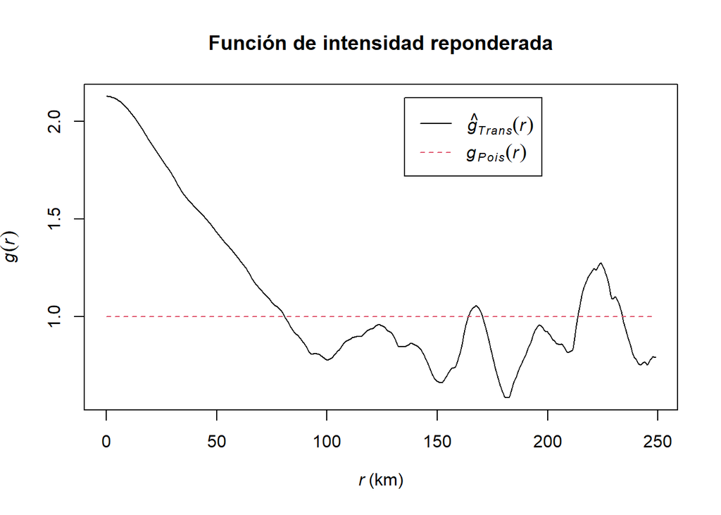

Figure 2.9: Función de correlación por pares reponderada

```r
plot(
  pcfinhom(
    unmark(sismos_ppp),
    lambda = lambda_s,
    correction = "translate"
  ), main = "Función de intensidad reponderada"
)
```

La función de correlación por pares, mostrada en el gráfico 2.9, presenta valores superiores a la unidad para distancias cortas, lo que sugiere la posible existencia de agregación residual entre eventos incluso después de corregir la heterogeneidad espacial mediante un modelo inhomogéneo a distancias cortas.

# 3 Dependencia espacial de la magnitud sísmica

Analizar la magnitud (marca) de los sismos es importante porque no solo importa el espacio donde ocurrieron (los eventos) sino tambien sus carácterísicas.

## 3.1 Visualización

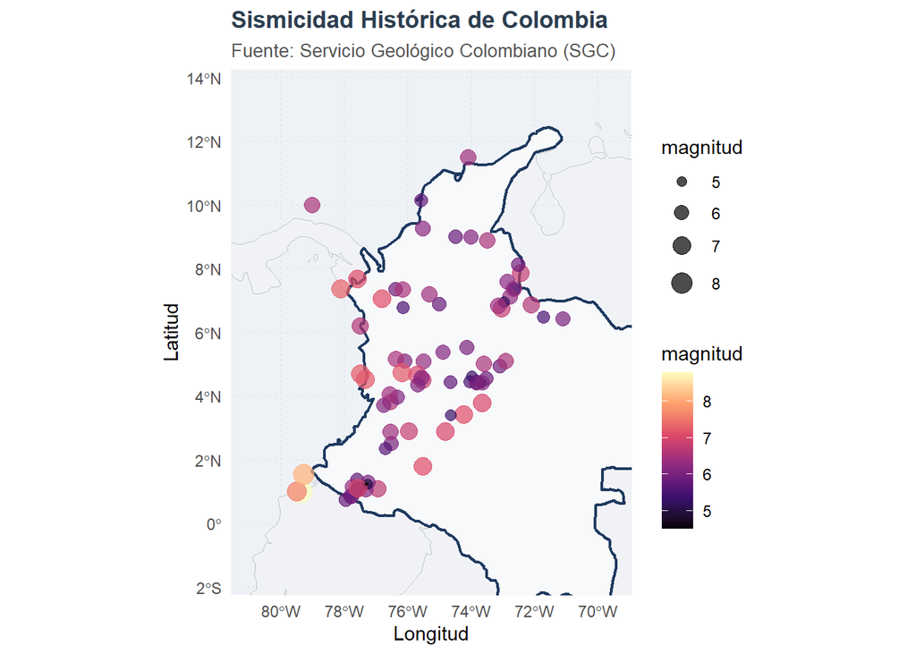

Figure 3.1: Visualización de sismos en Colombia en el año 1990 por magnitud

```r
# ==============================================================================
#  VISUALIZACIÓN CON GGPlot2 (Mapa profesional)
ggplot() +
  # Capa 1: Países vecinos (Fondo gris neutro y bordes sutiles)
  geom_sf(data = paises_vecinos,
          fill = "#f1f2f6",
          color = "#bdc3c7",
          linewidth = 0.3) +

  # Capa 2: Resaltar la frontera de Colombia (Línea más gruesa y azul oscuro)
  geom_sf(data = colombia_map,
          fill = "#f8f9fa",         # Un gris más limpio para diferenciarlo de los vecinos
          color = "#1f3a60",        # Tu azul oscuro elegante original
          linewidth = 0.8) +

  # Capa 4: Los sismos puros (Puntos rojos translúcidos)
 geom_sf(data = sismos_sf,
          aes(color = magnitudd, size = magnitudd),
          shape = 20,                             # Círculo sólido
          alpha = 0.7) +

  # Escala de colores: Paleta Magma (Amarillo = Alto, Negro/Morado = Bajo)
  scale_color_viridis_c(option = "magma",
                        name = "magnitud") +

  # Escala de tamaño: Los sismos más fuertes se ven más grandes en el mapa
  scale_size_continuous(range = c(1, 8.5),
                        name = "magnitud") +

  # Capa de Proyección y límites visuales (Explicado abajo)
  coord_sf(crs = st_crs(4326),
           xlim = c(-81, -69.5),
           ylim = c(-1.5, 13.5)) +

  # Etiquetas informativas
  labs(title = "Sismicidad Histórica de Colombia",
       subtitle = "Fuente: Servicio Geológico Colombiano (SGC)",
       x = "Longitud",
       y = "Latitud") +

  # Estética general limpia
  theme_minimal() +
  theme(
    panel.grid.major = element_line(color = "gray90", linetype = "dotted"),
    plot.title = element_text(face = "bold", size = 13, color = "#2c3e50"),
    plot.subtitle = element_text(size = 10, italic = TRUE, color = "#555555"),
    panel.background = element_rect(fill = "#eef2f7", color = NA), # Océano azul claro
    legend.position = "right"
  )
```

## 3.2 Correlación

```r
coords <- st_coordinates(sismos_sf)
datos <- cbind(sismos_sf$magnitudd, coords[,c(1,2)])

mat_cor <- cor(
  datos,
  method = "pearson",
  use = "complete.obs"
)
```

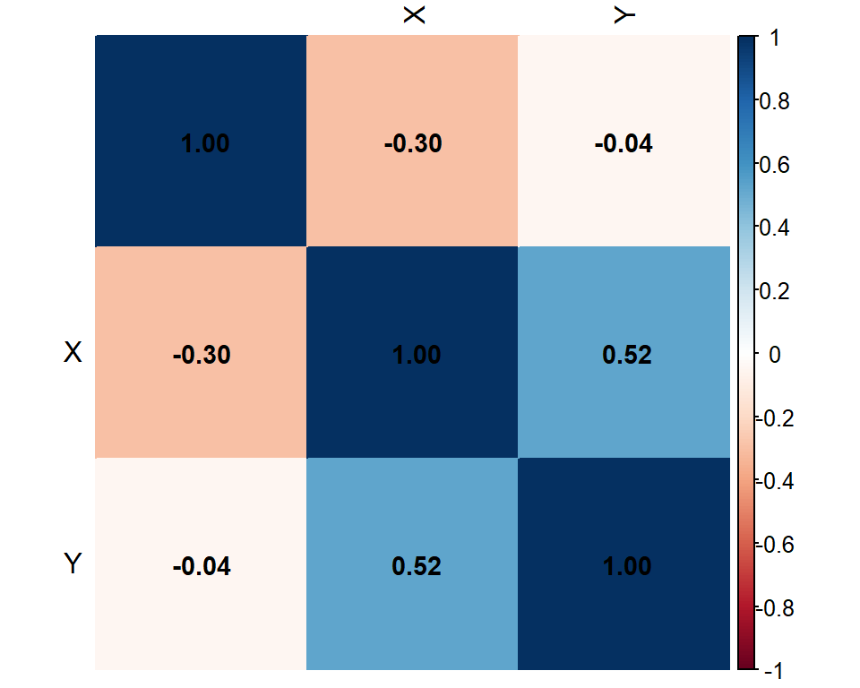

Figure 3.2: Correlación de pearson entre la variable magnitud y las coordenadas

```r
corrplot(
  mat_cor,
  method = "color",
  addCoef.col = "black",
  tl.col = "black",
  number.cex = 0.9
)
```

# 4 Discusión

Podemos ver en la figura 3.1 una clara concentración sobre la región andina, mostrando que los sismos no se comportan de manera uniforme a través de todo el territorio. Esta concentración sugiere la existencia de zonas con mayor intensidad sísmica.

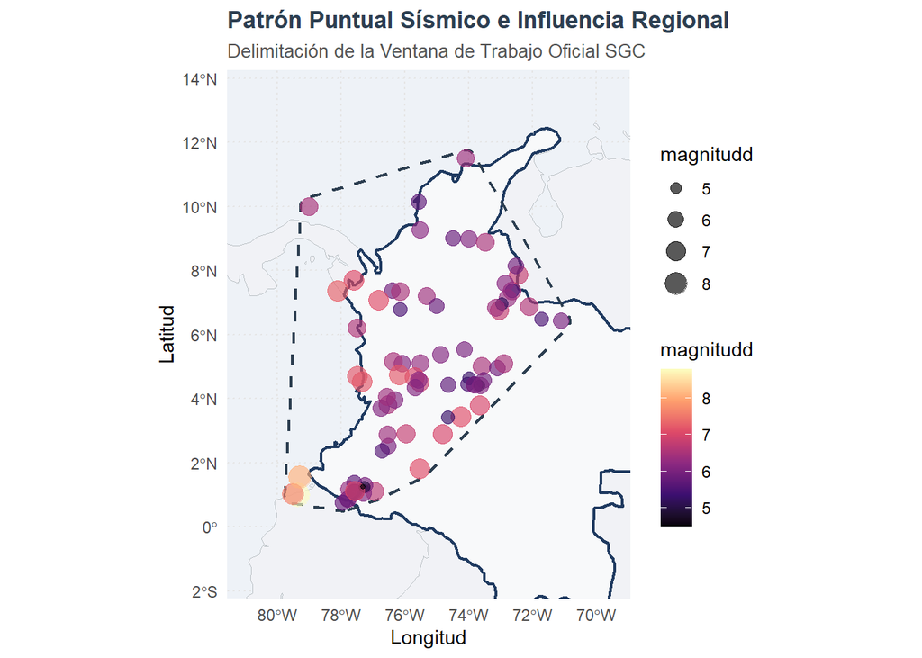

Figure 4.1: Patrón puntual sísmico e influencia regional

```r
ggplot() +
  # Capa 1: Países vecinos (Fondo gris neutro y bordes sutiles)
  geom_sf(data = paises_vecinos,
          fill = "#f1f2f6",
          color = "#bdc3c7",
          linewidth = 0.3) +

  # Capa 2: Resaltar la frontera de Colombia (Línea más gruesa y azul oscuro)
  geom_sf(data = colombia_map,
          fill = "#f8f9fa",         # Un gris más limpio para diferenciarlo de los vecinos
          color = "#1f3a60",        # Tu azul oscuro elegante original
          linewidth = 0.8) +

  # Capa 3: Delimitación de la Ventana de Trabajo del SGC (Línea discontinua roja o negra)
  geom_sf(data = ventana_sf,
          fill = NA,                # Totalmente transparente por dentro
          color = "#2c3e50",        # Color del marco
          linewidth = 0.8,
          style = "dashed",         # Línea discontinua tipo 'mira cartográfica'
          linetype = "dashed") +

  # Capa 4: Los sismos puros (Puntos rojos translúcidos)
  geom_sf(data = sismos_sf,
          aes(color = magnitudd, size = magnitudd),
          alpha = 0.65,
          shape = 19) +
  # Escala de colores: Paleta Magma (Amarillo = Alto, Negro/Morado = Bajo)
  scale_color_viridis_c(option = "magma",
                        name = "magnitudd") +

  # Capa de Proyección y límites visuales (Explicado abajo)
  coord_sf(crs = st_crs(4326),
           xlim = c(-81, -69.5),
           ylim = c(-1.5, 13.5)) +

  # Etiquetas y títulos adaptados
  labs(title = "Patrón Puntual Sísmico e Influencia Regional",
       subtitle = "Delimitación de la Ventana de Trabajo Oficial SGC",
       x = "Longitud", y = "Latitud") +

  # Estética profesional de fondo de océano
  theme_minimal() +
  theme(
    panel.grid.major = element_line(color = "gray90", linetype = "dotted"),
    plot.title = element_text(face = "bold", size = 13, color = "#2c3e50"),
    plot.subtitle = element_text(size = 10, italic = TRUE, color = "#555555"),
    panel.background = element_rect(fill = "#eef2f7", color = NA) # Océano azul claro
  )
```

Al mirar el mapa (Figura 4.1) se observan algunos eventos de mayor magnitud (tonos más claros y tamaños mayores), pero son pocos respecto al total de sismos. Además, esos eventos parecen concentrarse principalmente en dos zonas que coinciden con los focos de concentración identificados previamente en el análisis sin marca:

1. Suroccidente colombiano, asociado a la interacción entre las placas de Nazca y Sudamericana.
2. Centro-sur andino, aproximadamente entre Huila, Tolima, Meta y Caquetá.

Sin embargo, visualmente no parece que exista una separación espacial muy marcada entre sismos de baja y alta magnitud; más bien, las magnitudes elevadas se encuentran inmersas dentro de los mismos conglomerados espaciales donde se concentra la actividad sísmica general.

## 4.1 Magnitud promedio espacial

### 4.1.1 Magnitud promedio por cuadrantes

```r
tabla_final %>%
  select(id, Exp, n_sismos, magnitud_media ) %>%
  kableExtra::kbl(
  caption = "Magnitud promedio por cuadrantes",
  col.names = c("Id", "Frecuencia esperada", "Número de sismos observados", "Magnitud promedio"),
  align = c("l", "c", "c", "c")
) %>%
  kableExtra::kable_styling(
    full_width = FALSE,
    position = "center"
  ) %>%
  # Encabezado azul oscuro unificado con tu tema Flatly
  kableExtra::row_spec(0,
                       bold = TRUE,
                       background = "#2c3e50",
                       color = "white") %>%
  # Resaltar en azul claro las dos pruebas reinas confirmatorias de Clúster
  kableExtra::row_spec(5:8, bold = TRUE, background = "#e8f4fd")
```

Table 4.1: Magnitud promedio por cuadrantes

| Id | Frecuencia esperada | Número de sismos observados | Magnitud promedio |
| --- | --- | --- | --- |
| 1 | 7.6 | 1 | 6.500000 |
| 2 | 12.0 | 5 | 6.040000 |
| 3 | 4.5 | 2 | 6.200000 |
| 4 | 11.9 | 5 | 7.080000 |
| 5 | 13.3 | 21 | 6.195238 |
| 6 | 10.1 | 17 | 6.100000 |
| 7 | 12.4 | 17 | 6.300000 |
| 8 | 8.6 | 12 | 6.366667 |
| 9 | 0.6 | 1 | 7.000000 |

### 4.1.2 Gráfico ilustrativo de los cuadrantes

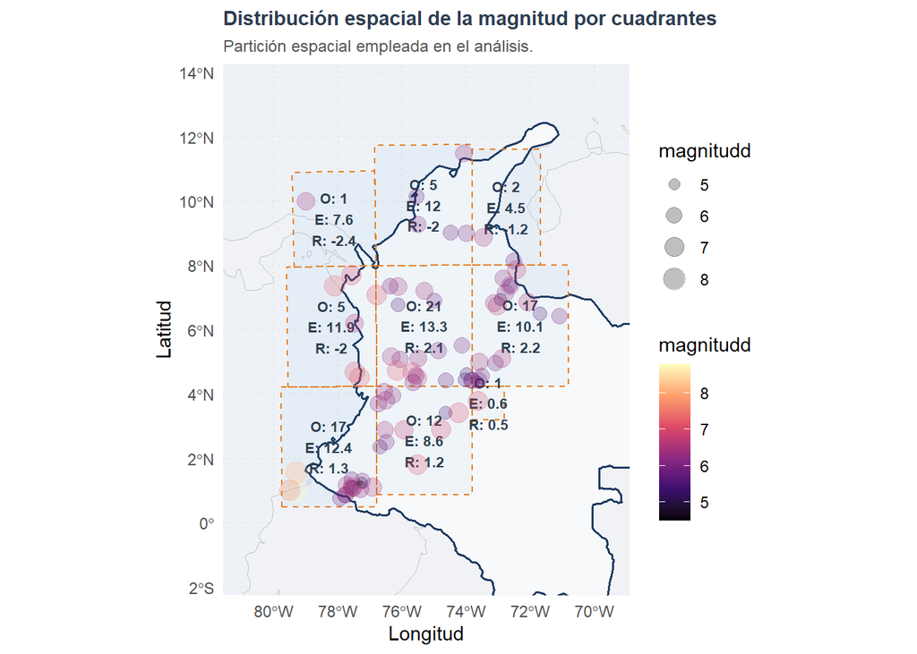

Figure 4.2: Magnitud por cuadrantes

### 4.1.3 Estimación de la magnitud promedio espacial

```r
mag_media <- Smooth.ppp(
  sismos_ppp,
  sigma = bw.diggle(sismos_ppp),
  at = "pixels"
)
```

```r
raster_mag <- st_as_stars(mag_media)

sf_mag <- st_as_sf(raster_mag)

# Como sismos_ppp está en kilómetros, regresamos a metros
st_geometry(sf_mag) <- st_geometry(sf_mag) * 1000

st_crs(sf_mag) <- 9377

# Transformar a coordenadas geográficas
sf_mag <- st_transform(sf_mag, 4326)

g_magnitud <- ggplot() +

  geom_sf(
    data = sf_mag,
    aes(fill = v),
    color = NA,
    alpha = 0.85
  ) +

  scale_fill_viridis_c(
    option = "magma",
    name = "Magnitud\nmedia"
  ) +

  geom_sf(
    data = paises_vecinos,
    fill = NA,
    color = "#bdc3c7",
    linewidth = 0.3
  ) +

  geom_sf(
    data = colombia_map,
    fill = NA,
    color = "#2c3e50",
    linewidth = 0.7
  ) +

  geom_sf(
    data = sismos_sf,
    aes(size = magnitudd),
    colour = "white",
    fill = "#1f78b4",
    shape = 21,
    alpha = 0.35,
    stroke = 0.2
  ) +

  # Capa de Proyección y límites visuales (Explicado abajo)
  coord_sf(crs = st_crs(4326),
           xlim = c(-81, -69.5),
           ylim = c(-1.5, 13.5)) +

  labs(
    title = "Superficie suavizada de la magnitud sísmica",
    x = "Longitud",
    y = "Latitud"
  ) +

  theme_minimal() +

  theme(
    panel.background = element_rect(fill = "#eef2f7", colour = NA),
    panel.grid.major = element_line(
      colour = "gray90",
      linetype = "dotted"
    ),
    plot.title = element_text(
      face = "bold",
      size = 11,
      colour = "#2c3e50"
    ),
    plot.subtitle = element_text(
      size = 9,
      colour = "#555555",
      face = "italic"
    )
  )
```

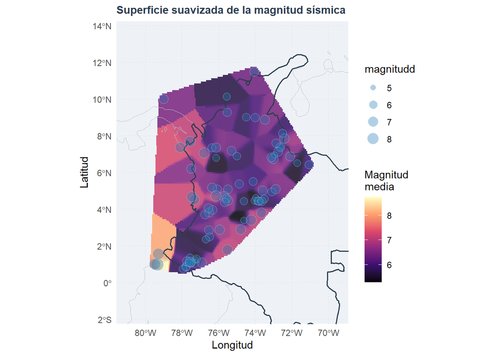

Figure 4.3: Estimación Kernel de la magnitud media espacial

```r
g_magnitud
```

## 4.2 Discusión

En la tabla 4.1 la magnitud promedio por cuadrante oscila entre 6.04 y 7.08, sin embargo, los valores más elevados corresponden a cuadrantes con muy pocos eventos observados, por lo que es díficil interpretar a la alta variabilidad asociada a tamaños muestrales reducidos. En contraste, los cuadrantes que concentran la mayor cantidad de sismos (5, 6, 7 y 8) presentan magnitudes promedio relativamente similares, comprendidas entre 6.10 y 6.37, esto sugiere que las zonas con mayor concentración de eventos identificadas en el análisis espacial no marcado no se caracterizan necesariamente por magnitudes significativamente mayores, sino principalmente por una mayor frecuencia de ocurrencia de sismos.

Por otro lado observese que en la figura 4.2 podemos ver que el cuadrante 7 contiene ese hot spot del suroccidente colombiano, conteniendo uno de los pocos sismos con alta magnitud, sin embargo su promedio no es muy alejado de los otros cuadrantes destacados en la tabla 4.1.

## 4.3 Función de correlación de marcas

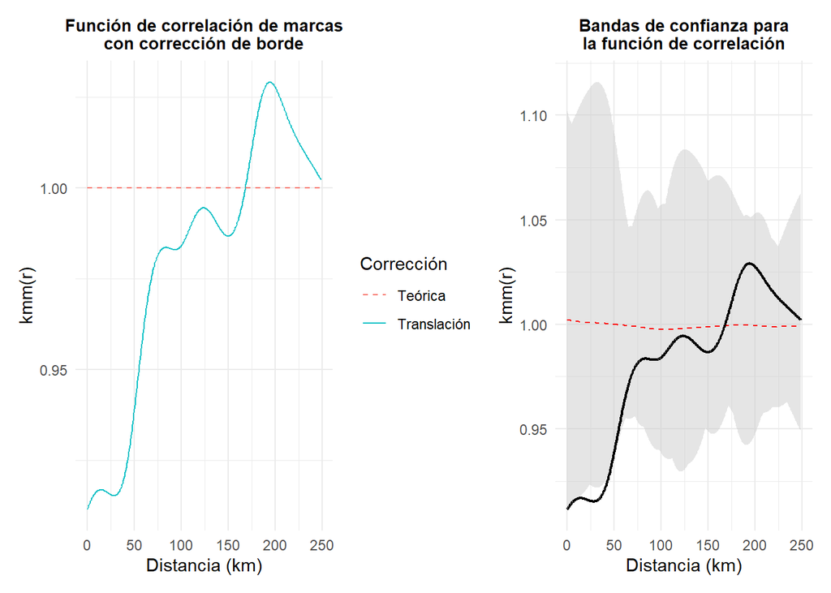

Figure 4.4: La función de correlación de marcas

```r
mosaico_mc
```

La función de correlación de marcas se utilizó para evaluar si las magnitudes sísmicas presentan dependencia espacial. La curva observada mostró ligeras fluctuaciones alrededor del valor teórico de referencia ($k_{mm}(r)=1$), con una leve tendencia positiva entre aproximadamente 180 y 220 km. Sin embargo, al comparar la función observada con las envolventes Monte Carlo (4.4) obtenidas mediante permutación aleatoria de las marcas, se encontró que la curva permanece completamente dentro de las bandas de simulación. En consecuencia, no existe evidencia estadística suficiente para rechazar la hipótesis de independencia entre la magnitud de los sismos y su localización espacial. Esto sugiere que las zonas donde se concentra la actividad sísmica no presentan necesariamente magnitudes mayores que las esperadas bajo una asignación aleatoria de las marcas.

[figure not shown]

```r
mosaico_mc
```

# 5 Conclusiones

- El análisis espacial sugiere que la distribución de los sismos está determinada principalmente por su ubicación geográfica, sin evidenciar interacción espacial significativa entre eventos una vez considerada la variación de la intensidad.
- La intensidad de ocurrencia y la intensidad marcada describen características diferentes del proceso espacial. Mientras la primera identifica las zonas con mayor concentración de sismos, la segunda refleja la distribución espacial de la magnitud promedio. En consecuencia, una mayor concentración de eventos no implica necesariamente que estos presenten magnitudes más elevadas.

# 6 Ejercicios de clase: Prueba de Homogeneidad con Índice de Clark-Evans

## 6.1 6. Para 3 eventos en una región de área $16u^2$ , sin eventos en el borde:

1. ¿Cuál es la probabilidad de que un evento esté dentro de la distancia ( 4u ) de un evento específico?

Dado que los eventos se distribuyen aleatoriamente en el área de ( 16u^2 ), la probabilidad de que un segundo evento caiga dentro de un círculo de radio ( r = 4u ) alrededor de un evento específico es:

2. Dada la homogeneidad del patrón, ¿cuánto es el valor de la intensidad en cada punto del área?

$$\lambda = \frac{n}{A} = \frac{3}{16} = 0.1875,\hspace{1cm}\text{eventos por unidad de área}.$$

## 6.2 7. Con base en el enunciado anterior, si este es el patrón observado:

| x | 2.3 | 3.9 | 1.8 |
| --- | --- | --- | --- |
| y | 3.8 | 2.4 | 3.5 |

**Cuadro 1.1: Patrón observado**

Realice la prueba de la hipótesis de homogeneidad usando el índice de Clark-Evans:

- **Asumiendo normalidad.**
- **Usando Montecarlo** a partir de la siguiente información relacionada:  
  Se hizo una simulación aleatoria de patrones homogéneos en la misma ventana, con los siguientes resultados para el índice de Clark-Evans:  
  4.089047, 2.036709, 1.999559, 2.042786, 2.246962, 2.132787, 3.592137, 2.841816, 2.414787, 2.561401, 3.379868, 3.254646, 3.834864, 2.236916, 3.011672, 3.905689, 4.086589, 4.031859, 1.993797.

El índice de Clark-Evans se define como:

$$R = \frac{\bar{r}_{\text{obs}}}{\bar{r}_{\text{esp}}},$$

donde:

- ( $\bar{r}_{\text{obs}}$ ) es la distancia promedio observada al vecino más cercano.
- ( $\bar{r}_{\text{esp}}$ ) es la distancia esperada bajo un patrón aleatorio homogéneo.

Para un patrón Poisson en un área ( A ) con ( n ) puntos:

$$\bar{r}_{\text{esp}} = \frac{1}{2\sqrt{\lambda}} = \frac{1}{2\sqrt{0.1875}} \approx 1.1547.$$

Datos observados:

| Punto | x | y |
| --- | --- | --- |
| A | 2.3 | 3.8 |
| B | 3.9 | 2.4 |
| C | 1.8 | 3.5 |

Entonces:

$$\bar{r}_{\text{obs}} = \frac{0.583 + 2.126 + 0.583}{3} = \frac{3.292}{3} \approx 1.0973.$$

Por lo tanto:

$$R = \frac{1.0973}{1.1547} \approx 0.9503.$$

### 6.2.2 Prueba de hipótesis bajo normalidad

El estadístico de prueba ( Z ) se aproxima como:

$$Z = \frac{R - 1}{\text{SE}(R)},$$

donde:

$$\text{SE}(R) \approx \frac{0.26136}{\sqrt{n \cdot \lambda}} = \frac{0.26136}{\sqrt{3 \cdot 0.1875}} = \frac{0.26136}{\sqrt{0.5625}} = \frac{0.26136}{0.75} \approx 0.3485.$$

Entonces:

$$Z = \frac{0.9503 - 1}{0.3485} = \frac{-0.0497}{0.3485} \approx -0.1426.$$

## 6.3 4. Prueba de Clark-Evans usando Montecarlo

Resultados de la simulación (19 valores):

$$\begin{aligned}
&4.089047,\ 2.036709,\ 1.999559,\ 2.042786,\ 2.246962,\ 2.132787,\ 3.592137,\ 2.841816,\\
&2.414787,\ 2.561401,\ 3.379868,\ 3.254646,\ 3.834864,\ 2.236916,\ 3.011672,\ 3.905689,\\
&4.086589,\ 4.031859,\ 1.993797.
\end{aligned}$$

### 6.3.1 Cálculo del ( R ) observado

Ya calculamos:

$$R_{\text{obs}} \approx 0.9503.$$

### 6.3.2 Determinación del p-valor empírico

Ninguno de los 19 valores es menor que 0.9503. Por lo tanto, el p-valor empírico es:

$$p = \frac{0 + 1}{19 + 1} = \frac{1}{20} = 0.05.$$

## 6.4 Resumen de resultados

[output not shown]

**Nota:** La discrepancia entre ambas pruebas puede deberse a que la aproximación normal no es adecuada para muestras muy pequeñas (( n = 3 )), por lo que el método de Montecarlo es más fiable en este contexto.

# Referencias

Bohorquez, Martha. 2026. “Patrones Puntuales.” Documento de clase.

Carrillo, W., N. Bernal, and P. Porras. 2013. “EVALUACIÓN DEL DISEÑO DE UNA PEQUEÑA MESA VIBRATORIA PARA ENSAYOS EN INGENIERÍA SISMO - RESISTENTE.” *Ciencia e Ingeniería Neogranadina* 23 (1): 89–106.